# SQL_Capstone_Analysis

## Introduction ## Data Importation ## Load Data ## Data Cleaning ## Exploratory Data Analysis ## Visualizations ## Insights ## Recommendations ## Limitations ## Conclusion

## Introduction

# SQL Capstone Analysis This notebook analyzes the sales data from my SQL Capstone project. - Shows total sales - Top products and customers - Average sales per customer - Discount impact on sales - Visualizations to support insights

## Importing Required Libraries

```python
import pandas as pd                               # for data analysis
import numpy as np                                # for numerical operations
import matplotlib.pyplot as plt                   # for charts
import seaborn as sns                             # for nicer charts
from matplotlib.ticker import FormatStrFormatter  # for control on how numbers appear on the axis (e.g., forcing 2 decimal places)
```

## Loading my cleaned dataset

```python
# Loading categories table
categories = pd.read_csv('categories_cleaned.csv')
print("First 5 rows of the dataset:")
categories.head()
```

```
First 5 rows of the dataset:
```

|  | CategoryID | CategoryName |
| --- | --- | --- |
| 0 | 1 | CONFECTIONS |
| 1 | 2 | SHELL FISH |
| 2 | 3 | CEREALS |
| 3 | 4 | DAIRY |
| 4 | 5 | BEVERAGES |

```python
# Loading cities table
cities = pd.read_csv('cities_cleaned.csv')
print("First 5 rows of the dataset:")
cities.head()
```

```
First 5 rows of the dataset:
```

|  | CityID | CityName | Zipcode | CountryID |
| --- | --- | --- | --- | --- |
| 0 | 1 | DAYTON | 80563 | 32 |
| 1 | 2 | BUFFALO | 17420 | 32 |
| 2 | 3 | CHICAGO | 44751 | 32 |
| 3 | 4 | FREMONT | 20641 | 32 |
| 4 | 5 | VIRGINIA BEACH | 62389 | 32 |

```python
# Loading countries table
countries = pd.read_csv('countries_cleaned.csv')
print("First 5 rows of the dataset:")
countries.head()
```

```
First 5 rows of the dataset:
```

|  | CountryID | CountryName | CountryCode |
| --- | --- | --- | --- |
| 0 | 1 | ARMENIA | AN |
| 1 | 2 | CANADA | FO |
| 2 | 3 | BELIZE | MK |
| 3 | 4 | UGANDA | LV |
| 4 | 5 | THAILAND | VI |

```python
# Loading customers table
customers = pd.read_csv('customers_cleaned.csv')
print("First 5 rows of the dataset:")
customers.head()
```

```
First 5 rows of the dataset:
```

|  | CustomerID | FirstName | MiddleInitial | LastName | CityID | Address |
| --- | --- | --- | --- | --- | --- | --- |
| 0 | 1 | STEFANIE | Y | FRYE | 79 | 97 OAK AVENUE |
| 1 | 2 | SANDY | T | KIRBY | 96 | 52 WHITE FIRST FREEWAY |
| 2 | 3 | LEE | T | ZHANG | 55 | 921 WHITE FABIEN AVENUE |
| 3 | 4 | REGINA | S | AVERY | 40 | 75 OLD AVENUE |
| 4 | 5 | DANIEL | S | MCCANN | 2 | 283 SOUTH GREEN HAGUE AVENUE |

```python
# Loading employees table
employees = pd.read_csv('employees_cleaned.csv')
print("First 5 rows of the dataset:")
employees.head()
```

```
First 5 rows of the dataset:
```

|  | EmployeeID | FirstName | MiddleInitial | LastName | BirthDate | Gender | CityID | HireDate |
| --- | --- | --- | --- | --- | --- | --- | --- | --- |
| 0 | 1 | NICOLE | T | FULLER | 1981-03-07 | F | 80 | 2011-06-20 |
| 1 | 2 | CHRISTINE | W | PALMER | 1968-01-25 | F | 4 | 2011-04-27 |
| 2 | 3 | PABLO | Y | CLINE | 1963-02-09 | M | 70 | 2012-03-30 |
| 3 | 4 | DARNELL | O | NIELSEN | 1989-02-06 | M | 39 | 2014-03-06 |
| 4 | 5 | DESIREE | L | STUART | 1963-05-03 | F | 23 | 2014-11-16 |

```python
# Loading products table
products = pd.read_csv('products_cleaned.csv')
print("First 5 rows of the dataset:")
products.head()
```

```
First 5 rows of the dataset:
```

|  | ProductID | ProductName | Price | CategoryID | Class | ModifyDate | Resistant | IsAllergic | VitalityDays |
| --- | --- | --- | --- | --- | --- | --- | --- | --- | --- |
| 0 | 1 | FLOUR - WHOLE WHEAT | 74.30 | 3 | MEDIUM | 2018-02-16 | DURABLE | UNKNOWN | 0 |
| 1 | 2 | COOKIE CHOCOLATE CHIP WITH | 91.23 | 3 | MEDIUM | 2017-02-12 | UNKNOWN | UNKNOWN | 0 |
| 2 | 3 | ONIONS - CIPPOLINI | 9.14 | 9 | MEDIUM | 2018-03-15 | WEAK | FALSE | 111 |
| 3 | 4 | SAUCE - GRAVY, AU JUS, MIX | 54.31 | 9 | MEDIUM | 2017-07-16 | DURABLE | UNKNOWN | 0 |
| 4 | 5 | ARTICHOKES - JERUSALEM | 65.48 | 2 | LOW | 2017-08-16 | DURABLE | TRUE | 27 |

```python
# Loading sales table
sales = pd.read_csv('sales_cleaned.csv')
print("First 5 rows of the dataset:")
sales.head()
```

```
First 5 rows of the dataset:
```

|  | SalesID | SalesPersonID | CustomerID | ProductID | UnitPrice | Quantity | Discount | SalesDate | TransactionNumber |
| --- | --- | --- | --- | --- | --- | --- | --- | --- | --- |
| 0 | 1 | 6 | 27039 | 381 | 44.23 | 7 | 0.0 | 2018-02-05 | FQL4S94E4ME1EZFTG42G |
| 1 | 2 | 16 | 25011 | 61 | 62.55 | 7 | 0.0 | 2018-02-02 | 12UGLX40DJ1A5DTFBHB8 |
| 2 | 3 | 13 | 94024 | 23 | 79.02 | 24 | 0.0 | 2018-05-03 | 5DT8RCPL87KI5EORO7B0 |
| 3 | 4 | 8 | 73966 | 176 | 81.32 | 19 | 0.2 | 2018-04-07 | R3DR9MLD5NR76VO17ULE |
| 4 | 5 | 10 | 32653 | 310 | 79.98 | 9 | 0.0 | 2018-02-12 | 4BGS0Z5OMAZ8NDAFHHP3 |

## Data Cleaning

```python
# Data cleaning of categories table
# Check missing values
print('\nMISSING VALUE RESULT:')
print(categories.isnull().sum())

# Check duplicates
print('\nDUPLICATES RESULT:')
print(categories.duplicated().sum())
```

```
MISSING VALUE RESULT:
CategoryID      0
CategoryName    0
dtype: int64

DUPLICATES RESULT:
0
```

```python
# Data cleaning of cities table
# Check missing values
print('\nMISSING VALUE RESULT:')
print(cities.isnull().sum())

# Check duplicates
print('\nDUPLICATES RESULT:')
print(cities.duplicated().sum())
```

```
MISSING VALUE RESULT:
CityID       0
CityName     0
Zipcode      0
CountryID    0
dtype: int64

DUPLICATES RESULT:
0
```

```python
# Data cleaning of countries table
# Check missing values
print('\nMISSING VALUE RESULT:')
print(countries.isnull().sum())

# Check duplicates
print('\nDUPLICATES RESULT:')
print(countries.duplicated().sum())
```

```
MISSING VALUE RESULT:
CountryID      0
CountryName    0
CountryCode    1
dtype: int64

DUPLICATES RESULT:
0
```

```python
# Data cleaning of customers table
# Check missing values
print('\nMISSING VALUE RESULT:')
print(customers.isnull().sum())

# Check duplicates
print('\nDUPLICATES RESULT:')
print(customers.duplicated().sum())
```

```
MISSING VALUE RESULT:
CustomerID       0
FirstName        0
MiddleInitial    9
LastName         0
CityID           0
Address          0
dtype: int64

DUPLICATES RESULT:
0
```

```python
# Data cleaning of employees table
# Check missing values
print('\nMISSING VALUE RESULT:')
print(employees.isnull().sum())

# Check duplicates
print('\nDUPLICATES RESULT:')
print(employees.duplicated().sum())
```

```
MISSING VALUE RESULT:
EmployeeID       0
FirstName        0
MiddleInitial    0
LastName         0
BirthDate        0
Gender           0
CityID           0
HireDate         0
dtype: int64

DUPLICATES RESULT:
0
```

```python
# Data cleaning of products table
# Check missing values
print('\nMISSING VALUE RESULT:')
print(products.isnull().sum())

# Check duplicates
print('\nDUPLICATES RESULT:')
print(products.duplicated().sum())
```

```
MISSING VALUE RESULT:
ProductID       0
ProductName     0
Price           0
CategoryID      0
Class           0
ModifyDate      0
Resistant       0
IsAllergic      0
VitalityDays    0
dtype: int64

DUPLICATES RESULT:
0
```

```python
# Data cleaning of sales table
# Check missing values
print('\nMISSING VALUE RESULT:')
print(sales.isnull().sum())

# Check duplicates
print('\nDUPLICATES RESULT:')
print(sales.duplicated().sum())

# Check basic stats
print('\nDATASET INFO:')
sales.describe(include='all')
```

```
MISSING VALUE RESULT:
SalesID              0
SalesPersonID        0
CustomerID           0
ProductID            0
UnitPrice            0
Quantity             0
Discount             0
SalesDate            0
TransactionNumber    0
dtype: int64

DUPLICATES RESULT:
0

DATASET INFO:
```

|  | SalesID | SalesPersonID | CustomerID | ProductID | UnitPrice | Quantity | Discount | SalesDate | TransactionNumber |
| --- | --- | --- | --- | --- | --- | --- | --- | --- | --- |
| count | 50.00000 | 50.000000 | 50.000000 | 50.000000 | 50.000000 | 50.000000 | 50.000000 | 50 | 50 |
| unique | NaN | NaN | NaN | NaN | NaN | NaN | NaN | 41 | 50 |
| top | NaN | NaN | NaN | NaN | NaN | NaN | NaN | 2018-02-07 | FQL4S94E4ME1EZFTG42G |
| freq | NaN | NaN | NaN | NaN | NaN | NaN | NaN | 3 | 1 |
| mean | 25.50000 | 12.160000 | 48310.360000 | 265.660000 | 55.614600 | 12.720000 | 0.034000 | NaN | NaN |
| std | 14.57738 | 6.437644 | 28621.027035 | 134.910947 | 29.581276 | 7.236641 | 0.071742 | NaN | NaN |
| min | 1.00000 | 1.000000 | 655.000000 | 2.000000 | 0.430000 | 1.000000 | 0.000000 | NaN | NaN |
| 25% | 13.25000 | 6.250000 | 24099.750000 | 145.500000 | 35.770000 | 7.000000 | 0.000000 | NaN | NaN |
| 50% | 25.50000 | 13.000000 | 45433.000000 | 309.000000 | 59.570000 | 12.000000 | 0.000000 | NaN | NaN |
| 75% | 37.75000 | 17.000000 | 73149.250000 | 377.750000 | 80.985000 | 18.750000 | 0.000000 | NaN | NaN |
| max | 50.00000 | 23.000000 | 96120.000000 | 449.000000 | 98.830000 | 25.000000 | 0.200000 | NaN | NaN |

## Exploratory Data Analysis

1. Total sales

```python
# Calculate total sales after discount
# Assuming 'Discount' is in decimal (e.g., 0.10 for 10%)
sales['totalSalesAfterDiscount'] = round(sales['UnitPrice'] * sales['Quantity'] * (1 - sales['Discount']), 2)
print(sales['totalSalesAfterDiscount'].tail())

# Sum it up
total_sales = round(sales['totalSalesAfterDiscount'].sum(), 2)
print("\nTotal Sales:", total_sales)
```

```
45     503.42
46    1534.94
47     331.56
48    1896.00
49     422.20
Name: totalSalesAfterDiscount, dtype: float64

Total Sales: 34017.16
```

2. Top products by sales

```python
top_products = sales.groupby('ProductID')['totalSalesAfterDiscount'].sum().sort_values(ascending=False).head(10)
print(top_products)
```

```
ProductID
369    2005.14
23     1896.48
108    1896.00
215    1712.28
377    1689.30
407    1534.94
324    1494.30
176    1236.06
147    1190.88
2      1185.99
Name: totalSalesAfterDiscount, dtype: float64
```

3. Top customer

```python
top_customers = sales.groupby('CustomerID')['totalSalesAfterDiscount'].sum().sort_values(ascending=False).head(10)
print(top_customers)
```

```
CustomerID
87577    2005.14
94024    1896.48
93402    1896.00
74923    1712.28
96120    1689.30
86775    1534.94
66030    1494.30
73966    1236.06
91382    1190.88
51149    1185.99
Name: totalSalesAfterDiscount, dtype: float64
```

4. Average slaes per customer

```python
avg_sales_per_customer = sales.groupby('CustomerID')['totalSalesAfterDiscount'].mean()
print(avg_sales_per_customer.head())
```

```
CustomerID
655       90.79
2657      61.43
12687    184.67
13389    224.36
14612    193.68
Name: totalSalesAfterDiscount, dtype: float64
```

5. Sales distribution

```python
sales['totalSalesAfterDiscount'].describe()
```

```
count      50.000000
mean      680.343200
std       573.098258
min         6.190000
25%       226.715000
50%       437.625000
75%      1142.990000
max      2005.140000
Name: totalSalesAfterDiscount, dtype: float64
```

6. Discount impact

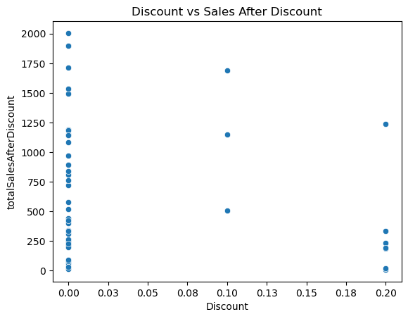

```python
sns.scatterplot(x='Discount', y='totalSalesAfterDiscount', data=sales)

plt.title('Discount vs Sales After Discount')

# Format x-axis to 2 decimal places
plt.gca().xaxis.set_major_formatter(FormatStrFormatter('%.2f'))

plt.show()
```

## Visualizations

1. Top 10 products by sales(bar chart)

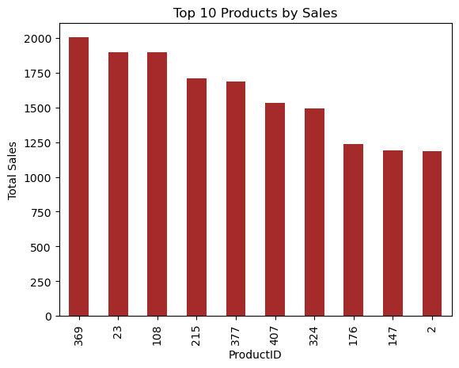

```python
top_products.plot(kind='bar', title='Top 10 Products by Sales', color='brown')
plt.ylabel('Total Sales')
plt.show()
```

2. Top 10 customers by sales(bar chart)

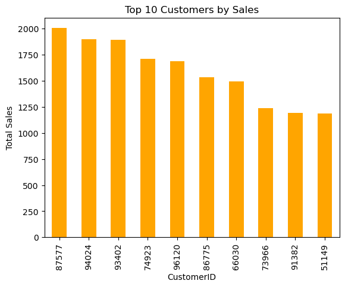

```python
top_customers.plot(kind='bar', title='Top 10 Customers by Sales', color='orange')
plt.ylabel('Total Sales')
plt.show()
```

3. Sales distribution histogram

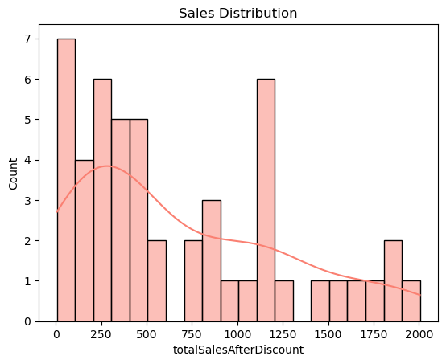

```python
sns.histplot(sales['totalSalesAfterDiscount'], bins=20, kde=True, color='salmon')
plt.title('Sales Distribution')
plt.show()
```

4. Sales by product category

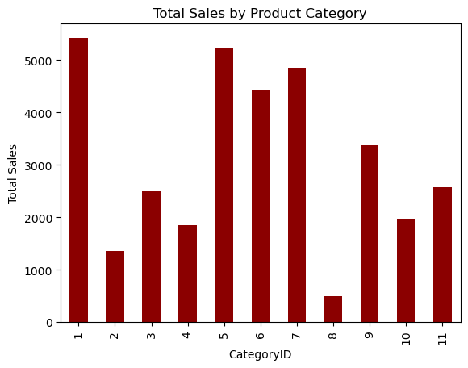

```python
category_sales = sales.merge(products, on='ProductID')
category_sales_grouped = category_sales.groupby('CategoryID')['totalSalesAfterDiscount'].sum()
category_sales_grouped.plot(kind='bar', title='Total Sales by Product Category', color='darkred')
plt.ylabel('Total Sales')
plt.show()
```

5. Trend Analysis(Sales over time)

```
Month
2018-01     2678.38
2018-02     5773.11
2018-03     6527.94
2018-04    13555.95
2018-05     5481.78
Freq: M, Name: totalSalesAfterDiscount, dtype: float64
```

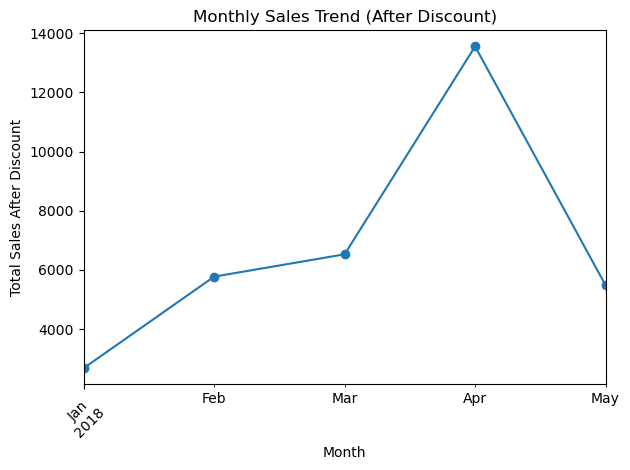

```python
sales['SalesDate'] = pd.to_datetime(sales['SalesDate'])
sales['Month'] = sales['SalesDate'].dt.to_period('M')
monthly_sales = sales.groupby('Month')['totalSalesAfterDiscount'].sum()
print(monthly_sales)

monthly_sales.plot(kind='line', marker='o')
plt.title('Monthly Sales Trend (After Discount)')
plt.xlabel('Month')
plt.ylabel('Total Sales After Discount')
plt.xticks(rotation=45)
plt.tight_layout()
plt.show()
```

6. Anomaly Detection

```python
# Months in 'anomalies' may indicate special events, issues, or opportunities.

monthly_sales = sales.groupby('Month')['totalSalesAfterDiscount'].sum()
print(monthly_sales)

# ==============================
# Anomaly detection in monthly sales
# ==============================

# Calculate mean and standard deviation of monthly sales
mean = monthly_sales.mean()
std = monthly_sales.std()

print("\nAverage Monthly Sales:", round(mean, 2))
print("\nStandard Deviation of Monthly Sales:", round(std, 2))

# Define anomalies: months where sales are much higher or lower than usual
# Here we use 2 standard deviations from the mean as the threshold
anomalies = monthly_sales[
    (monthly_sales > mean + 2 * std) | (monthly_sales < mean - 2 * std)
]

print("\nAnomalies (months with unusually high or low sales):")
print('\n',anomalies)
```

```
Month
2018-01     2678.38
2018-02     5773.11
2018-03     6527.94
2018-04    13555.95
2018-05     5481.78
Freq: M, Name: totalSalesAfterDiscount, dtype: float64

Average Monthly Sales: 6803.43

Standard Deviation of Monthly Sales: 4046.5

Anomalies (months with unusually high or low sales):

 Series([], Freq: M, Name: totalSalesAfterDiscount, dtype: float64)
```